# LAB_1022

RGT

10/22/2020

### Instructions

1-) Open book and open notes exam ( textbooks (print or pdf), lecture slides, notes, practice exam, homework solutions, and TA slides, including all Rmd’s*).

2-) You are allowed to use RStudio Cloud (https://rstudio.cloud.) , Microsoft Word, Power Point and PDF reader, and canvas on your laptop.

3-) You need to have a camera on your laptop. Proctorio is required to start this exam. If you are prompted for an access code, you must Configure Proctorio on your machine.

4-)Please read the list of recording and restrictions provided by Proctorio carefully before taking the exam

5-)Please pay attention any timing and technical warnings that popped up your screen The exam will be available from Friday October 23rd at 12 pm EST through Monday October 26th at 7:20 pm EST.

6-)Once you start the exam, you have to complete the exam in 3 hours or by Monday October 26th at 7:20 pm EST, whichever comes first.

7-)In order to receive full credit, please provide full explanations and calculations for each questions

8-)Make sure that you are familiar with the procedures for troubleshooting exam issues preview the document. Follow the protocol if there are any issues!

Please submit two files: (1) a R Markdown file (.Rmd extension) and (2) a PDF document, word, or html generated using knitr for the .Rmd file submitted in (1) where appropriate. Please, use RStudio Cloud for your solutions.

## Problem 1: Refer to the PM Q1 Data set. (40 Points)

```r
library(readr)
PM.Q1 <- read_csv("PM Q1.csv")
```

a- ) Build a regression model to predict Y as a function of X. Write down the regression model, Is the regression model significant? (5 points)

```r
f.q1.a<-lm(Y~X,data=PM.Q1)
summary(f.q1.a)
```

```
##
## Call:
## lm(formula = Y ~ X, data = PM.Q1)
##
## Residuals:
##     Min      1Q  Median      3Q     Max
## -239405  -39840   -7641   23515  388362
##
## Coefficients:
##               Estimate Std. Error t value Pr(>|t|)
## (Intercept) -81432.946  11551.846  -7.049 5.74e-12 ***
## X              158.950      4.875  32.605  < 2e-16 ***
## ---
## Signif. codes:  0 '***' 0.001 '**' 0.01 '*' 0.05 '.' 0.1 ' ' 1
##
## Residual standard error: 79120 on 520 degrees of freedom
## Multiple R-squared:  0.6715, Adjusted R-squared:  0.6709
## F-statistic:  1063 on 1 and 520 DF,  p-value: < 2.2e-16
```

The model is significant. Y= -81432.946 + 158.95*X. $R^{2}$ is 67%.

b-) Check all the assumptions related to the regression model and perform Brown-Forsythe Test. (10 points) *A1) normal linear regression model is appropriate for the problem. +Plot the predictor variable X against the response values Y; to ascertain whether any departures from linear regression model are evident. State your findings.* A2) The estimated errors (residuals) are independent from the X and from the estimated values Y_hat. +Plot the residuals ei against the fitted values Y_hat and the predictor variable values X; to ascertain whether any departures from linear regression model are evident. State your findings. *A3) Errors are iid~N(0,sigma) that is the errors are independent and identically normally distributed. +Obtain the residuals ei and prepare a box plot of the residuals. What information is provided by your plot? +Prepare a normal probability plot of the residuals (QQ plot). Also obtain the coefficient of correlation between the ordered residuals and their expected values under normality. Does the normality assumption appear to be reasonable here? +Correlation Test of Normality of Residuals (Shapiro Test)* A4) Error terms have constant variance and mean=0 (homoscedastic). +Brown-Forsythe +Breush-Pagan

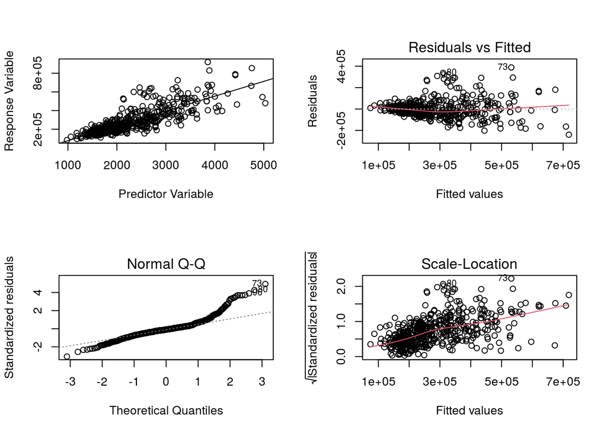

```r
#A1
f.q1.a<-lm(Y~X,data=PM.Q1)
par(mfrow=c(2,2))
plot(PM.Q1$X,PM.Q1$Y,xlab="Predictor Variable",ylab="Response Variable")
abline(f.q1.a)
#A2
plot(f.q1.a)
```

```r
#A3
ei<-f.q1.a$residuals
boxplot(ei,horizontal=TRUE,staplewex=0.5,col=3,xlab="Residual")
#Ho: Errors are normally distributed Ha: Errors are Not normally distributed
shapiro.test(f.q1.a$residuals)
```

```
##
##  Shapiro-Wilk normality test
##
## data:  f.q1.a$residuals
## W = 0.90048, p-value < 2.2e-16
```

```r
#A4 Ho: Do Errors have constant variance. Ha: Errors have not constant variance.
#Brown-Forsythe Test using the median X to split the data
library(onewaytests)
bf.dat<-data.frame(ei,yhat=f.q1.a$fitted.values,ind=as.factor(I(PM.Q1$X<=median(PM.Q1$X))*1))
bf.test(ei~ind,data=bf.dat)
```

```
##
##   Brown-Forsythe Test (alpha = 0.05)
## -------------------------------------------------------------
##   data : ei and ind
##
##   statistic  : 0.389263
##   num df     : 1
##   denom df   : 312.1958
##   p.value    : 0.5331427
##
##   Result     : Difference is not statistically significant.
## -------------------------------------------------------------
```

```r
#Breush Pagan Ho: Rho=0; Ha: Rho different from 0 so variable variance
ei2<-ei^2
g<-lm(ei2~PM.Q1$X)
ep=anova(g)
SSE=ep[2,2]
SSE
```

```
## [1] 1.061148e+23
```

```r
rr=anova(f.q1.a)
SSR=  rr[1,3]
```

[figure not shown]

#Obtain the sum of the regression of the residuals and SSE from regression #built the Xisquare statistic for the test

```r
ChiSquare=(SSR/2)/((SSE/522)^2)
ChiSquare
```

```
## [1] 8.052651e-29
```

```r
#critical value is 3.841459-can not reject null 0 is below
qchisq(0.95,1)
```

```
## [1] 3.841459
```

```r
# here the p-value is 0.25 can not reject null p*=0.05
1-pchisq(4183563,1)
```

```
## [1] 0
```

```r
install.packages("lmtest")
library(lmtest)
bptest(f.q1.a)
```

```
##
##  studentized Breusch-Pagan test
##
## data:  f.q1.a
## BP = 72.174, df = 1, p-value < 2.2e-16
```

QQ plot indicates the departure from the normality. Residual vs. Fitted plot indicates hetoradasticity. Shapiro-Wilk normality test:

Ho: Data is normally distributed Ha: Data is NOT normally distributed

P value is < 0.05, Reject Ho. Errors are Not normally distributed.

Ho: Error Variance is constant Ha: Error Variance is Not constant

c-)Do we need to transform Y? Use Box-Cox procedure to find out appropriate transformation of Y and justify your choice. (10 points)

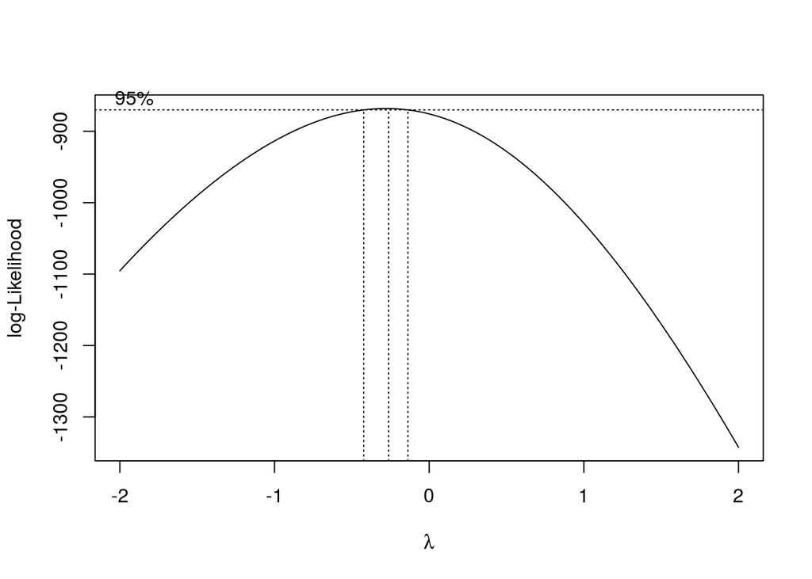

```r
library(MASS)
par(mfrow=c(1,1))
bc=boxcox(f.q1.a,lambda = seq(-2,2,0.1))
```

```r
best.lam=bc$x[which(bc$y==max(bc$y))]
best.lam
```

```
## [1] -0.2626263
```

```r
f.q1.a1<-lm(log(Y)~X,data=PM.Q1)
summary(f.q1.a1)
```

```
##
## Call:
## lm(formula = log(Y) ~ X, data = PM.Q1)
##
## Residuals:
##      Min       1Q   Median       3Q      Max
## -0.76772 -0.14834 -0.01448  0.11921  0.84182
##
## Coefficients:
##              Estimate Std. Error t value Pr(>|t|)
## (Intercept) 1.128e+01  3.427e-02  329.24   <2e-16 ***
## X           5.097e-04  1.446e-05   35.24   <2e-16 ***
## ---
## Signif. codes:  0 '***' 0.001 '**' 0.01 '*' 0.05 '.' 0.1 ' ' 1
##
## Residual standard error: 0.2347 on 520 degrees of freedom
## Multiple R-squared:  0.7049, Adjusted R-squared:  0.7043
## F-statistic:  1242 on 1 and 520 DF,  p-value: < 2.2e-16
```

```
##
##  Shapiro-Wilk normality test
##
## data:  f.q1.a1$residuals
## W = 0.97549, p-value = 1.143e-07
```

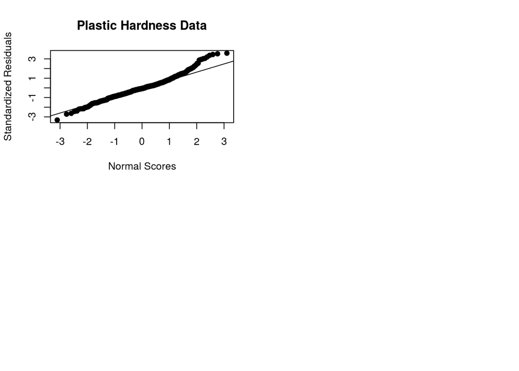

```r
par(mfrow=c(2,2))
error.std = rstandard(f.q1.a1)
qqnorm(error.std,ylab="Standardized Residuals",xlab="Normal Scores",main="Plastic Hardness Data", pch=19)
qqline(error.std)
shapiro.test(f.q1.a1$residuals)
```

plot(f.q1.a1)

[output not shown]

[output not shown]

```r
B=qt(1-0.1/(2*3),520)
S=sqrt(3*qf(0.90,3,520))
cbind(B,S)
```

```
##             B        S
## [1,] 2.133716 2.506601
```

```r
#including prediction standard deviation for Bonferroni=Chk PredictionSheffeBon and WorkingHotellin
s.pred<-sqrt(pred$se.fit^2+pred$residual.scale^2)
exp(cbind(pred$fit-B*s.pred,pred$fit+B*s.pred))
```

```
##        [,1]      [,2]
## 1  84160.65  229954.5
## 2 221828.97  605190.5
## 3 580722.72 1603617.9
```

Log transformation is used for the final. We need to transform it back to original scale. The predicted values are 139,115.5 366,399.8 965,016.8

Bonferroni procedure will yield somewhat tighter prediction limits as ( B ≤ S ). Please see below for the confidence intervals.

$84,160.65 \leq \hat{Y_{1}} \leq 229,954.5$ $221,828.97 \leq \hat{Y_{2}} \leq 605,190.5$ $580,722.72 \leq \hat{Y_{3}} \leq 1,603,617.9$ ## Problem 2

Copy and paste the data below in R. (30 points)

y=c(98,135,162,178,221,232,283,300,374,395)\ x=c(0,1,2,3,4,5,6,7,8,9)

a-) is the linear fit appropriate? If not, transform the data and find an appropriate fit. Comment on the model and regression model assumptions. (20 points) ##############RESCUE CODE### graphics.off() par(“mar”) par(mar=c(1,1,1,1)) #######################

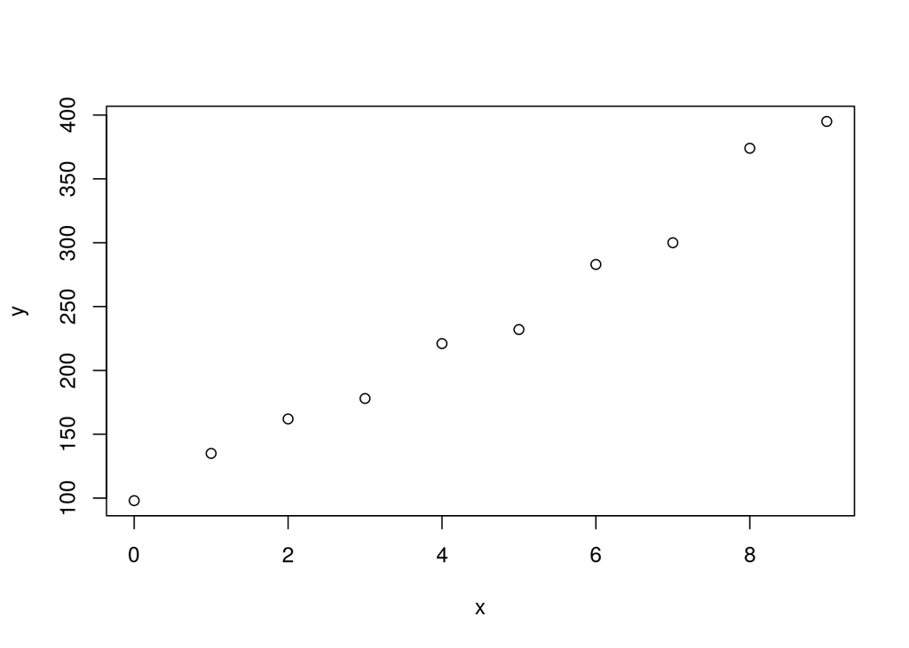

```r
y=c(98,135,162,178,221,232,283,300,374,395)
x=c(0,1,2,3,4,5,6,7,8,9)
par(mfrow=c(1,1))
plot(x,y)
```

```r
f2<-lm(y~x)
summary(f2)
```

```
##
## Call:
## lm(formula = y ~ x)
##
## Residuals:
##     Min      1Q  Median      3Q     Max
## -22.049  -9.177   2.446   9.814  22.461
##
## Coefficients:
##             Estimate Std. Error t value Pr(>|t|)
## (Intercept)   91.564      8.814   10.39 6.38e-06 ***
## x             32.497      1.651   19.68 4.62e-08 ***
## ---
## Signif. codes:  0 '***' 0.001 '**' 0.01 '*' 0.05 '.' 0.1 ' ' 1
##
## Residual standard error: 15 on 8 degrees of freedom
## Multiple R-squared:  0.9798, Adjusted R-squared:  0.9772
## F-statistic: 387.4 on 1 and 8 DF,  p-value: 4.62e-08
```

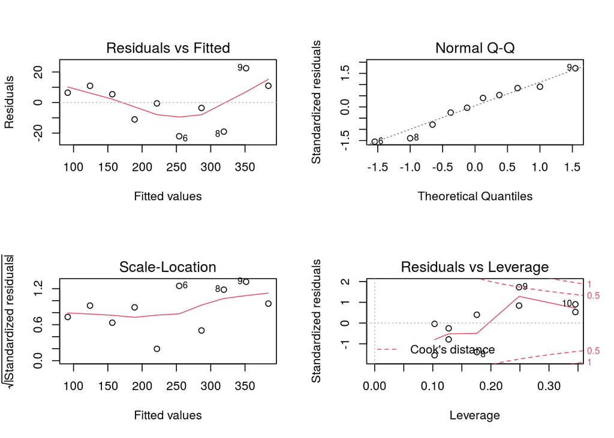

```r
par(mfrow=c(2,2))
plot(f2)
```

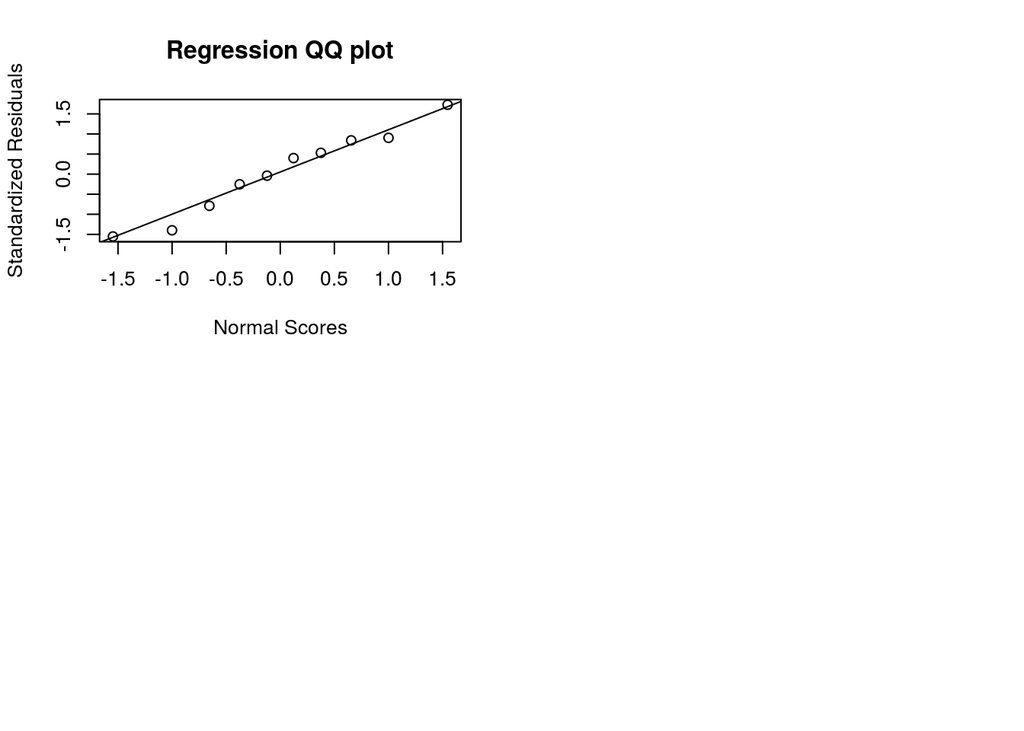

```r
error.std = rstandard(f2)
qqnorm(error.std,ylab="Standardized Residuals",xlab="Normal Scores",main="Regression QQ plot")
qqline(error.std)
```

#Quantitative corroboration of QQ plot

```r
shapiro.test(f2$residuals)
```

```
##
##  Shapiro-Wilk normality test
##
## data:  f2$residuals
## W = 0.96123, p-value = 0.7998
```

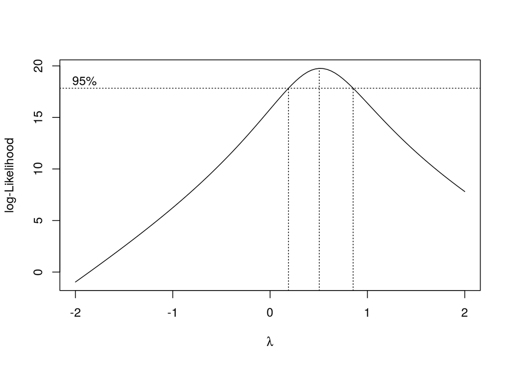

```r
par(mfrow=c(1,1))
bc1=boxcox(f2,lambda=seq(-2,2,0.1))
```

```r
best.lam1=bc1$x[which(bc1$y==max(bc1$y))]
best.lam1
```

```
## [1] 0.5050505
```

```r
f21<-lm(sqrt(y)~x)
summary(f21)
```

```
##
## Call:
## lm(formula = sqrt(y) ~ x)
##
## Residuals:
##      Min       1Q   Median       3Q      Max
## -0.47447 -0.30811  0.01549  0.29541  0.46781
##
## Coefficients:
##             Estimate Std. Error t value Pr(>|t|)
## (Intercept) 10.26093    0.21290   48.20 3.80e-11 ***
## x            1.07629    0.03988   26.99 3.83e-09 ***
## ---
## Signif. codes:  0 '***' 0.001 '**' 0.01 '*' 0.05 '.' 0.1 ' ' 1
##
## Residual standard error: 0.3622 on 8 degrees of freedom
## Multiple R-squared:  0.9891, Adjusted R-squared:  0.9878
## F-statistic: 728.4 on 1 and 8 DF,  p-value: 3.826e-09
```

The scatter plot indicates linear relationship between x and Y. However, QQ plot indicates a slight s function, which indicates slight departure from the normal distribution. Boxcox transfomration indicates, square root transformation. The model is Y=91.564 + 32.497X and $R^{2}$ is 98%. There is a slight increase of the power of the model, $R^{2}$ is 99% and the model is $\sqrt{Y}=10.26+1.08X$.QQ plot shows the S shape, this is could be due to low sample size (10). However the final model is $\sqrt{Y}=10.26+1.08X$.

b-) Predict Y when x=10, and calculate the prediction confidence interval for 90% confidence level (10 points)

See below, we need to transform it back to original scale.

```r
pred<-predict.lm(f21,data.frame(x = 10),interval =  "prediction",level=0.90)
pred^2
```

```
##        fit      lwr      upr
## 1 442.0022 408.3675 476.9679
```

## Problem 3

Refer to the PM Q3 Data set. (30 Points)

Perform one factor analysis by finding the best variable to explain Y. Fit one variable regression model with Y as a dependent variable against remaining variables, as an independent variable one at time. Choice the best variable explain Y and comment on the QQ plot and error vs. fitted values graph for the model assumptions.

```r
library(readr)
PM.Q3 <- read_csv("PM Q3.csv")
```

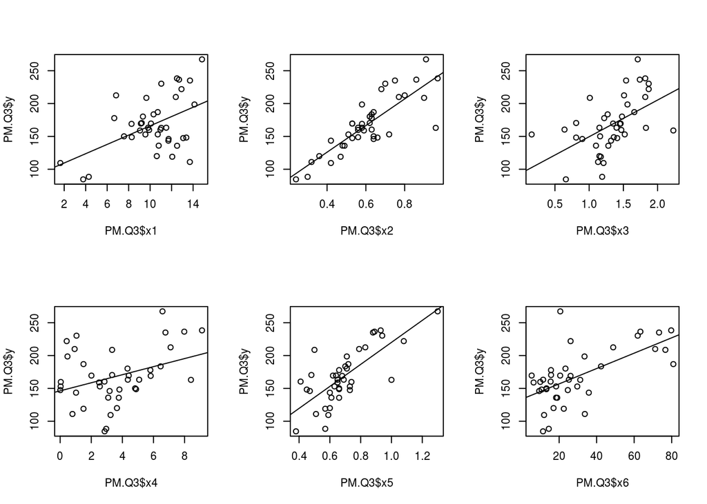

```r
f1<-lm(y~x1,data=PM.Q3)
f2<-lm(y~x2,data=PM.Q3)
f3<-lm(y~x3,data=PM.Q3)
f4<-lm(y~x4,data=PM.Q3)
f5<-lm(y~x5,data=PM.Q3)
f6<-lm(y~x6,data=PM.Q3)
par(mfrow=c(2,3))
plot(PM.Q3$x1,PM.Q3$y);abline(f1)
plot(PM.Q3$x2,PM.Q3$y);abline(f2)
plot(PM.Q3$x3,PM.Q3$y);abline(f3)
plot(PM.Q3$x4,PM.Q3$y);abline(f4)
plot(PM.Q3$x5,PM.Q3$y);abline(f5)
plot(PM.Q3$x6,PM.Q3$y);abline(f6)
```

```r
a=summary(f1)$r.squared
b=summary(f2)$r.squared
c=summary(f3)$r.squared
d=summary(f4)$r.squared
e=summary(f5)$r.squared
f=summary(f6)$r.squared

h=anova(f2)[2,3]
i=anova(f5)[2,3]

gt=cbind(a,b,c,d,e,f)
gt
```

```
##              a         b         c         d         e         f
## [1,] 0.2308528 0.6920204 0.2836212 0.1281442 0.5470451 0.3867451
```

```r
rg=cbind(h,i)
rg
```

```
##             h        i
## [1,] 550.8068 810.0881
```

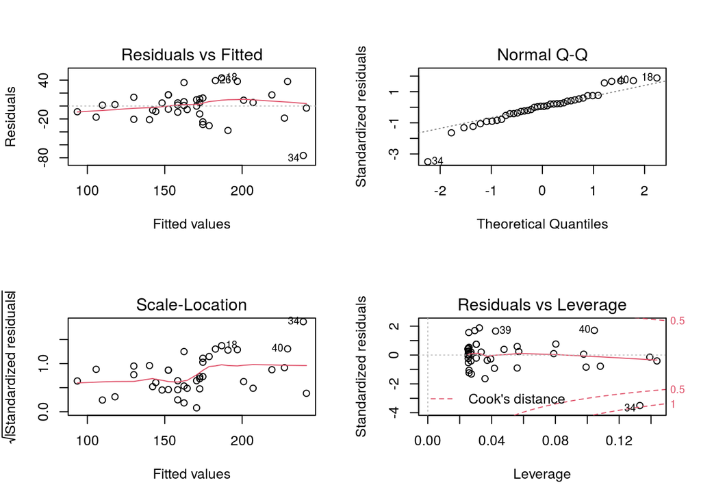

```r
par(mfrow=c(2,2))
plot(f2)
```

All variables are significant. The $R^{2}$s are below.

model with x1: $R^{2}$ is 0.2309 model with x2: $R^{2}$ is 0.692 model with x3: $R^{2}$ is 0.2836 model with x4: $R^{2}$ is 0.1281 model with x5: $R^{2}$ is 0.547 model with x6: $R^{2}$ is 0.3867

x2 is the most signficiant variable as it has the highest $R^{2}$. QQ plot roughly looks normal, however, observation 34 looks like an outlier. Residual vs. Fitted plot indicates heterodasticity and more test needed to for this.